# Risk Factor Analysis

## Outcome Variable

**Outcome Variable:** haz

## Predictor Variables

**Intervention Variable:** safeh20

**Adjustment Set:**

unadjusted

## Stratifying Variables

The analysis was stratified on these variable(s):

- agecat
- studyid
- country

## Data Summary

| agecat | studyid | country | safeh20 | n_cell | n |
| --- | --- | --- | --- | --- | --- |
| Birth | MAL-ED | BANGLADESH | 1 | 0 | 213 |
| Birth | MAL-ED | BANGLADESH | 0 | 213 | 213 |
| Birth | MAL-ED | BRAZIL | 1 | 0 | 41 |
| Birth | MAL-ED | BRAZIL | 0 | 41 | 41 |
| Birth | MAL-ED | INDIA | 1 | 0 | 41 |
| Birth | MAL-ED | INDIA | 0 | 41 | 41 |
| Birth | MAL-ED | NEPAL | 1 | 1 | 26 |
| Birth | MAL-ED | NEPAL | 0 | 25 | 26 |
| Birth | MAL-ED | PERU | 1 | 9 | 207 |
| Birth | MAL-ED | PERU | 0 | 198 | 207 |
| Birth | MAL-ED | SOUTH AFRICA | 1 | 13 | 96 |
| Birth | MAL-ED | SOUTH AFRICA | 0 | 83 | 96 |
| Birth | MAL-ED | TANZANIA, UNITED REPUBLIC OF | 1 | 79 | 119 |
| Birth | MAL-ED | TANZANIA, UNITED REPUBLIC OF | 0 | 40 | 119 |
| Birth | NIH-Birth | BANGLADESH | 1 | 606 | 608 |
| Birth | NIH-Birth | BANGLADESH | 0 | 2 | 608 |
| Birth | NIH-Crypto | BANGLADESH | 1 | 732 | 732 |
| Birth | NIH-Crypto | BANGLADESH | 0 | 0 | 732 |
| Birth | PROVIDE | BANGLADESH | 1 | 45 | 45 |
| Birth | PROVIDE | BANGLADESH | 0 | 0 | 45 |
| 6 months | CONTENT | PERU | 1 | 54 | 57 |
| 6 months | CONTENT | PERU | 0 | 3 | 57 |
| 6 months | LCNI-5 | MALAWI | 1 | 672 | 816 |
| 6 months | LCNI-5 | MALAWI | 0 | 144 | 816 |
| 6 months | MAL-ED | BANGLADESH | 1 | 0 | 240 |
| 6 months | MAL-ED | BANGLADESH | 0 | 240 | 240 |
| 6 months | MAL-ED | BRAZIL | 1 | 0 | 142 |
| 6 months | MAL-ED | BRAZIL | 0 | 142 | 142 |
| 6 months | MAL-ED | INDIA | 1 | 0 | 235 |
| 6 months | MAL-ED | INDIA | 0 | 235 | 235 |
| 6 months | MAL-ED | NEPAL | 1 | 1 | 233 |
| 6 months | MAL-ED | NEPAL | 0 | 232 | 233 |
| 6 months | MAL-ED | PERU | 1 | 11 | 259 |
| 6 months | MAL-ED | PERU | 0 | 248 | 259 |
| 6 months | MAL-ED | SOUTH AFRICA | 1 | 37 | 248 |
| 6 months | MAL-ED | SOUTH AFRICA | 0 | 211 | 248 |
| 6 months | MAL-ED | TANZANIA, UNITED REPUBLIC OF | 1 | 168 | 246 |
| 6 months | MAL-ED | TANZANIA, UNITED REPUBLIC OF | 0 | 78 | 246 |
| 6 months | NIH-Birth | BANGLADESH | 1 | 535 | 537 |
| 6 months | NIH-Birth | BANGLADESH | 0 | 2 | 537 |
| 6 months | NIH-Crypto | BANGLADESH | 1 | 715 | 715 |
| 6 months | NIH-Crypto | BANGLADESH | 0 | 0 | 715 |
| 6 months | PROVIDE | BANGLADESH | 1 | 11 | 11 |
| 6 months | PROVIDE | BANGLADESH | 0 | 0 | 11 |
| 6 months | SAS-FoodSuppl | INDIA | 1 | 380 | 380 |
| 6 months | SAS-FoodSuppl | INDIA | 0 | 0 | 380 |
| 24 months | CONTENT | PERU | 1 | 45 | 48 |
| 24 months | CONTENT | PERU | 0 | 3 | 48 |
| 24 months | LCNI-5 | MALAWI | 1 | 475 | 574 |
| 24 months | LCNI-5 | MALAWI | 0 | 99 | 574 |
| 24 months | MAL-ED | BANGLADESH | 1 | 0 | 212 |
| 24 months | MAL-ED | BANGLADESH | 0 | 212 | 212 |
| 24 months | MAL-ED | BRAZIL | 1 | 0 | 113 |
| 24 months | MAL-ED | BRAZIL | 0 | 113 | 113 |
| 24 months | MAL-ED | INDIA | 1 | 0 | 227 |
| 24 months | MAL-ED | INDIA | 0 | 227 | 227 |
| 24 months | MAL-ED | NEPAL | 1 | 1 | 226 |
| 24 months | MAL-ED | NEPAL | 0 | 225 | 226 |
| 24 months | MAL-ED | PERU | 1 | 7 | 193 |
| 24 months | MAL-ED | PERU | 0 | 186 | 193 |
| 24 months | MAL-ED | SOUTH AFRICA | 1 | 34 | 237 |
| 24 months | MAL-ED | SOUTH AFRICA | 0 | 203 | 237 |
| 24 months | MAL-ED | TANZANIA, UNITED REPUBLIC OF | 1 | 145 | 213 |
| 24 months | MAL-ED | TANZANIA, UNITED REPUBLIC OF | 0 | 68 | 213 |
| 24 months | NIH-Birth | BANGLADESH | 1 | 427 | 429 |
| 24 months | NIH-Birth | BANGLADESH | 0 | 2 | 429 |
| 24 months | NIH-Crypto | BANGLADESH | 1 | 514 | 514 |
| 24 months | NIH-Crypto | BANGLADESH | 0 | 0 | 514 |
| 24 months | PROVIDE | BANGLADESH | 1 | 9 | 9 |
| 24 months | PROVIDE | BANGLADESH | 0 | 0 | 9 |

The following strata were considered:

- agecat: 24 months, studyid: CONTENT, country: PERU
- agecat: 24 months, studyid: LCNI-5, country: MALAWI
- agecat: 24 months, studyid: MAL-ED, country: BANGLADESH
- agecat: 24 months, studyid: MAL-ED, country: BRAZIL
- agecat: 24 months, studyid: MAL-ED, country: INDIA
- agecat: 24 months, studyid: MAL-ED, country: NEPAL
- agecat: 24 months, studyid: MAL-ED, country: PERU
- agecat: 24 months, studyid: MAL-ED, country: SOUTH AFRICA
- agecat: 24 months, studyid: MAL-ED, country: TANZANIA, UNITED REPUBLIC OF
- agecat: 24 months, studyid: NIH-Birth, country: BANGLADESH
- agecat: 24 months, studyid: NIH-Crypto, country: BANGLADESH
- agecat: 24 months, studyid: PROVIDE, country: BANGLADESH
- agecat: 6 months, studyid: CONTENT, country: PERU
- agecat: 6 months, studyid: LCNI-5, country: MALAWI
- agecat: 6 months, studyid: MAL-ED, country: BANGLADESH
- agecat: 6 months, studyid: MAL-ED, country: BRAZIL
- agecat: 6 months, studyid: MAL-ED, country: INDIA
- agecat: 6 months, studyid: MAL-ED, country: NEPAL
- agecat: 6 months, studyid: MAL-ED, country: PERU
- agecat: 6 months, studyid: MAL-ED, country: SOUTH AFRICA
- agecat: 6 months, studyid: MAL-ED, country: TANZANIA, UNITED REPUBLIC OF
- agecat: 6 months, studyid: NIH-Birth, country: BANGLADESH
- agecat: 6 months, studyid: NIH-Crypto, country: BANGLADESH
- agecat: 6 months, studyid: PROVIDE, country: BANGLADESH
- agecat: 6 months, studyid: SAS-FoodSuppl, country: INDIA
- agecat: Birth, studyid: MAL-ED, country: BANGLADESH
- agecat: Birth, studyid: MAL-ED, country: BRAZIL
- agecat: Birth, studyid: MAL-ED, country: INDIA
- agecat: Birth, studyid: MAL-ED, country: NEPAL
- agecat: Birth, studyid: MAL-ED, country: PERU
- agecat: Birth, studyid: MAL-ED, country: SOUTH AFRICA
- agecat: Birth, studyid: MAL-ED, country: TANZANIA, UNITED REPUBLIC OF
- agecat: Birth, studyid: NIH-Birth, country: BANGLADESH
- agecat: Birth, studyid: NIH-Crypto, country: BANGLADESH
- agecat: Birth, studyid: PROVIDE, country: BANGLADESH

### Dropped Strata

- agecat: Birth, studyid: MAL-ED, country: BANGLADESH
- agecat: Birth, studyid: MAL-ED, country: BRAZIL
- agecat: Birth, studyid: MAL-ED, country: INDIA
- agecat: Birth, studyid: MAL-ED, country: NEPAL
- agecat: Birth, studyid: NIH-Birth, country: BANGLADESH
- agecat: Birth, studyid: NIH-Crypto, country: BANGLADESH
- agecat: Birth, studyid: PROVIDE, country: BANGLADESH
- agecat: 6 months, studyid: CONTENT, country: PERU
- agecat: 6 months, studyid: MAL-ED, country: BANGLADESH
- agecat: 6 months, studyid: MAL-ED, country: BRAZIL
- agecat: 6 months, studyid: MAL-ED, country: INDIA
- agecat: 6 months, studyid: MAL-ED, country: NEPAL
- agecat: 6 months, studyid: NIH-Birth, country: BANGLADESH
- agecat: 6 months, studyid: NIH-Crypto, country: BANGLADESH
- agecat: 6 months, studyid: PROVIDE, country: BANGLADESH
- agecat: 6 months, studyid: SAS-FoodSuppl, country: INDIA
- agecat: 24 months, studyid: CONTENT, country: PERU
- agecat: 24 months, studyid: MAL-ED, country: BANGLADESH
- agecat: 24 months, studyid: MAL-ED, country: BRAZIL
- agecat: 24 months, studyid: MAL-ED, country: INDIA
- agecat: 24 months, studyid: MAL-ED, country: NEPAL
- agecat: 24 months, studyid: NIH-Birth, country: BANGLADESH
- agecat: 24 months, studyid: NIH-Crypto, country: BANGLADESH
- agecat: 24 months, studyid: PROVIDE, country: BANGLADESH

## Methods Detail

We’re interested in the causal parameters $E[Y_a]$ for all values of $a \in \mathcal{A}$. These parameters represent the mean outcome if, possibly contrary to fact, we intervened to set all units to have $A=a$. Under the randomization and positivity assumptions, these are identified by the statistical parameters $\psi_a=E_W[E_{Y|A,W}(Y|A=a,W)]$. In addition, we’re interested in the mean of $Y$, $E[Y]$ under no intervention (the observed mean). We will estimate these parameters by using SuperLearner to fit the relevant likelihood factors – $E_{Y|A,W}(Y|A=a,W)$ and $p(A=a|W)$, and then updating our likelihood fit using a joint TMLE.

For unadjusted analyses ($W=\{\}$), initial likelihoods were estimated using Lrnr_glm to estimate the simple $E(Y|A)$ and Lrnr_mean to estimate $p(A)$. For adjusted analyses, a small library containing Lrnr_glmnet, Lrnr_xgboost, and Lrnr_mean was used.

Having estimated these parameters, we will then use the delta method to estimate relative risks and attributable risks relative to a prespecified baseline level of $A$.

# Results Detail

## Results Plots

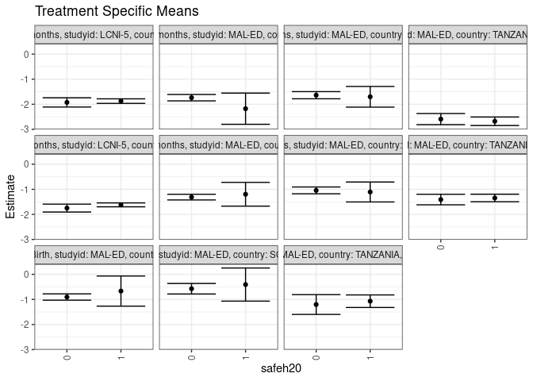

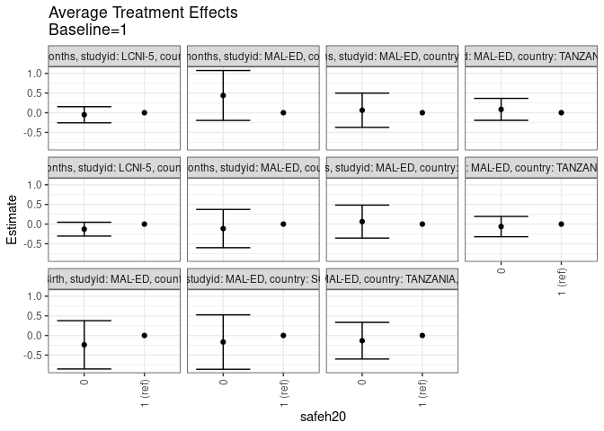

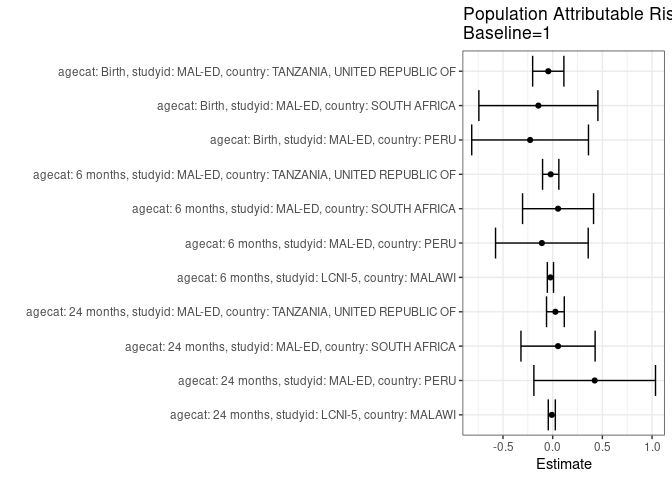

## Results Table

### Parameter: TSM

| agecat | studyid | country | intervention_level | baseline_level | estimate | ci_lower | ci_upper |
| --- | --- | --- | --- | --- | --- | --- | --- |
| Birth | MAL-ED | PERU | 1 | NA | -0.6677778 | -1.2689426 | -0.0666129 |
| Birth | MAL-ED | PERU | 0 | NA | -0.9054040 | -1.0308665 | -0.7799416 |
| Birth | MAL-ED | SOUTH AFRICA | 1 | NA | -0.4084615 | -1.0684465 | 0.2515234 |
| Birth | MAL-ED | SOUTH AFRICA | 0 | NA | -0.5749398 | -0.7848371 | -0.3650425 |
| Birth | MAL-ED | TANZANIA, UNITED REPUBLIC OF | 1 | NA | -1.0713924 | -1.3209812 | -0.8218036 |
| Birth | MAL-ED | TANZANIA, UNITED REPUBLIC OF | 0 | NA | -1.2037500 | -1.5978845 | -0.8096155 |
| 6 months | LCNI-5 | MALAWI | 1 | NA | -1.6200000 | -1.6970627 | -1.5429373 |
| 6 months | LCNI-5 | MALAWI | 0 | NA | -1.7486111 | -1.9061062 | -1.5911160 |
| 6 months | MAL-ED | PERU | 1 | NA | -1.1977273 | -1.6713269 | -0.7241276 |
| 6 months | MAL-ED | PERU | 0 | NA | -1.3113273 | -1.4241570 | -1.1984976 |
| 6 months | MAL-ED | SOUTH AFRICA | 1 | NA | -1.1074324 | -1.5045802 | -0.7102846 |
| 6 months | MAL-ED | SOUTH AFRICA | 0 | NA | -1.0439021 | -1.1799376 | -0.9078665 |
| 6 months | MAL-ED | TANZANIA, UNITED REPUBLIC OF | 1 | NA | -1.3459821 | -1.4962914 | -1.1956729 |
| 6 months | MAL-ED | TANZANIA, UNITED REPUBLIC OF | 0 | NA | -1.4087821 | -1.6186491 | -1.1989150 |
| 24 months | LCNI-5 | MALAWI | 1 | NA | -1.8733579 | -1.9639860 | -1.7827298 |
| 24 months | LCNI-5 | MALAWI | 0 | NA | -1.9250000 | -2.1090919 | -1.7409081 |
| 24 months | MAL-ED | PERU | 1 | NA | -2.1757143 | -2.7976265 | -1.5538020 |
| 24 months | MAL-ED | PERU | 0 | NA | -1.7370699 | -1.8647759 | -1.6093639 |
| 24 months | MAL-ED | SOUTH AFRICA | 1 | NA | -1.7010294 | -2.1129033 | -1.2891556 |
| 24 months | MAL-ED | SOUTH AFRICA | 0 | NA | -1.6380993 | -1.7799979 | -1.4962008 |
| 24 months | MAL-ED | TANZANIA, UNITED REPUBLIC OF | 1 | NA | -2.6762414 | -2.8460121 | -2.5064706 |
| 24 months | MAL-ED | TANZANIA, UNITED REPUBLIC OF | 0 | NA | -2.5904412 | -2.8122451 | -2.3686373 |

### Parameter: E(Y)

| agecat | studyid | country | intervention_level | baseline_level | estimate | ci_lower | ci_upper |
| --- | --- | --- | --- | --- | --- | --- | --- |
| Birth | MAL-ED | PERU | NA | NA | -0.8950725 | -1.0180716 | -0.7720734 |
| Birth | MAL-ED | SOUTH AFRICA | NA | NA | -0.5523958 | -0.7550074 | -0.3497843 |
| Birth | MAL-ED | TANZANIA, UNITED REPUBLIC OF | NA | NA | -1.1158824 | -1.3283278 | -0.9034369 |
| 6 months | LCNI-5 | MALAWI | NA | NA | -1.6426961 | -1.7120603 | -1.5733318 |
| 6 months | MAL-ED | PERU | NA | NA | -1.3065026 | -1.4164323 | -1.1965728 |
| 6 months | MAL-ED | SOUTH AFRICA | NA | NA | -1.0533804 | -1.1834360 | -0.9233247 |
| 6 months | MAL-ED | TANZANIA, UNITED REPUBLIC OF | NA | NA | -1.3658943 | -1.4882808 | -1.2435078 |
| 24 months | LCNI-5 | MALAWI | NA | NA | -1.8822648 | -1.9637218 | -1.8008078 |
| 24 months | MAL-ED | PERU | NA | NA | -1.7529793 | -1.8786399 | -1.6273186 |
| 24 months | MAL-ED | SOUTH AFRICA | NA | NA | -1.6471273 | -1.7822999 | -1.5119547 |
| 24 months | MAL-ED | TANZANIA, UNITED REPUBLIC OF | NA | NA | -2.6488498 | -2.7844961 | -2.5132034 |

### Parameter: ATE

| agecat | studyid | country | intervention_level | baseline_level | estimate | ci_lower | ci_upper |
| --- | --- | --- | --- | --- | --- | --- | --- |
| Birth | MAL-ED | PERU | 1 | 1 | 0.0000000 | 0.0000000 | 0.0000000 |
| Birth | MAL-ED | PERU | 0 | 1 | -0.2376263 | -0.8517435 | 0.3764910 |
| Birth | MAL-ED | SOUTH AFRICA | 1 | 1 | 0.0000000 | 0.0000000 | 0.0000000 |
| Birth | MAL-ED | SOUTH AFRICA | 0 | 1 | -0.1664782 | -0.8590365 | 0.5260801 |
| Birth | MAL-ED | TANZANIA, UNITED REPUBLIC OF | 1 | 1 | 0.0000000 | 0.0000000 | 0.0000000 |
| Birth | MAL-ED | TANZANIA, UNITED REPUBLIC OF | 0 | 1 | -0.1323576 | -0.5988729 | 0.3341577 |
| 6 months | LCNI-5 | MALAWI | 1 | 1 | 0.0000000 | 0.0000000 | 0.0000000 |
| 6 months | LCNI-5 | MALAWI | 0 | 1 | -0.1286111 | -0.3039490 | 0.0467268 |
| 6 months | MAL-ED | PERU | 1 | 1 | 0.0000000 | 0.0000000 | 0.0000000 |
| 6 months | MAL-ED | PERU | 0 | 1 | -0.1136000 | -0.6004544 | 0.3732544 |
| 6 months | MAL-ED | SOUTH AFRICA | 1 | 1 | 0.0000000 | 0.0000000 | 0.0000000 |
| 6 months | MAL-ED | SOUTH AFRICA | 0 | 1 | 0.0635304 | -0.3562696 | 0.4833304 |
| 6 months | MAL-ED | TANZANIA, UNITED REPUBLIC OF | 1 | 1 | 0.0000000 | 0.0000000 | 0.0000000 |
| 6 months | MAL-ED | TANZANIA, UNITED REPUBLIC OF | 0 | 1 | -0.0627999 | -0.3209414 | 0.1953416 |
| 24 months | LCNI-5 | MALAWI | 1 | 1 | 0.0000000 | 0.0000000 | 0.0000000 |
| 24 months | LCNI-5 | MALAWI | 0 | 1 | -0.0516421 | -0.2568330 | 0.1535488 |
| 24 months | MAL-ED | PERU | 1 | 1 | 0.0000000 | 0.0000000 | 0.0000000 |
| 24 months | MAL-ED | PERU | 0 | 1 | 0.4386444 | -0.1962443 | 1.0735331 |
| 24 months | MAL-ED | SOUTH AFRICA | 1 | 1 | 0.0000000 | 0.0000000 | 0.0000000 |
| 24 months | MAL-ED | SOUTH AFRICA | 0 | 1 | 0.0629301 | -0.3727020 | 0.4985621 |
| 24 months | MAL-ED | TANZANIA, UNITED REPUBLIC OF | 1 | 1 | 0.0000000 | 0.0000000 | 0.0000000 |
| 24 months | MAL-ED | TANZANIA, UNITED REPUBLIC OF | 0 | 1 | 0.0858002 | -0.1935188 | 0.3651192 |

### Parameter: PAR

| agecat | studyid | country | intervention_level | baseline_level | estimate | ci_lower | ci_upper |
| --- | --- | --- | --- | --- | --- | --- | --- |
| Birth | MAL-ED | PERU | 1 | NA | -0.2272947 | -0.8147485 | 0.3601591 |
| Birth | MAL-ED | SOUTH AFRICA | 1 | NA | -0.1439343 | -0.7428182 | 0.4549496 |
| Birth | MAL-ED | TANZANIA, UNITED REPUBLIC OF | 1 | NA | -0.0444899 | -0.2017071 | 0.1127272 |
| 6 months | LCNI-5 | MALAWI | 1 | NA | -0.0226961 | -0.0538206 | 0.0084285 |
| 6 months | MAL-ED | PERU | 1 | NA | -0.1087753 | -0.5749608 | 0.3574102 |
| 6 months | MAL-ED | SOUTH AFRICA | 1 | NA | 0.0540521 | -0.3031276 | 0.4112317 |
| 6 months | MAL-ED | TANZANIA, UNITED REPUBLIC OF | 1 | NA | -0.0199122 | -0.1018437 | 0.0620193 |
| 24 months | LCNI-5 | MALAWI | 1 | NA | -0.0089069 | -0.0443330 | 0.0265192 |
| 24 months | MAL-ED | PERU | 1 | NA | 0.4227350 | -0.1892366 | 1.0347066 |
| 24 months | MAL-ED | SOUTH AFRICA | 1 | NA | 0.0539021 | -0.3192448 | 0.4270490 |
| 24 months | MAL-ED | TANZANIA, UNITED REPUBLIC OF | 1 | NA | 0.0273916 | -0.0619430 | 0.1167263 |